# Assigment - kNN DIY

Emiel Maters - 634735 - Author

20 september, 2022

Choose a suitable dataset from [this](https://github.com/HAN-M3DM-Data-Mining/assignments/tree/master/datasets) folder and train your own kNN model. Follow all the steps from the CRISP-DM model.

# Set-up

Before we can start with this assignment the installation and activation of some packages is needed:

```r
library(tidyverse)
library(dplyr)
library(janitor)
library(googlesheets4)
library(class)
library(caret)
```

# Business Understanding

This assignment is based on the data and story of Georg Hoffmann, Andreas Bietenbeck, Ralf Lichtinghagen and Frank Klawonn (Hoffmann et al. 2018).

When laboratory have to make a diagnose, their way of making decisions is based on rules: “If…then…else”. This way of diagnosing can be seen as a decision tree. Those treebranches can be seen as established medical guidelines that lead at some point to a diagnosis, like shown in the example down below.

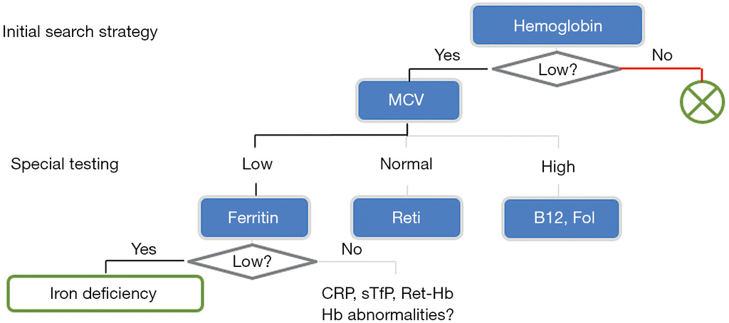

Example of an established diagnostic pathway for the differential diagnosis of anemia

## Data question

This data problem is about creating a KNN model that can determine in what stage a patient is:

- C0 = Blood Donor
- C1 = hepatitis without fibrosis or with only minor signs of portal fibrosis
- C2 = therapy-relevant fibrosis
- C3 = LTX-relevant end stage liver cirrhosis

# Data Understanding

As said, this data comes from an open source data set from Georg Hoffmann, Andreas Bietenbeck, Ralf Lichtinghagen and Frank Klawonn (Hoffmann et al. 2018). In the next code is the data written to a table called NewData.

```r
NewData<-read_csv("datasets/KNN-hcvdat0.csv")
```

```
## ──────────────────────────────────────────────────────── Delimiter: "," chr
## (2): Category, Sex dbl (12): ...1, Age, ALB, ALP, ALT, AST, BIL, CHE, CHOL,
## CREA, GGT, PROT
```

## Properties of the data

This section covers the properties of the dataset, without having made any changes to it.

```r
str(NewData)
```

```
## spec_tbl_df [615 × 14] (S3: spec_tbl_df/tbl_df/tbl/data.frame)
##  $ ...1    : num [1:615] 1 2 3 4 5 6 7 8 9 10 ...
##  $ Category: chr [1:615] "0=Blood Donor" "0=Blood Donor" "0=Blood Donor" "0=Blood Donor" ...
##  $ Age     : num [1:615] 32 32 32 32 32 32 32 32 32 32 ...
##  $ Sex     : chr [1:615] "m" "m" "m" "m" ...
##  $ ALB     : num [1:615] 38.5 38.5 46.9 43.2 39.2 41.6 46.3 42.2 50.9 42.4 ...
##  $ ALP     : num [1:615] 52.5 70.3 74.7 52 74.1 43.3 41.3 41.9 65.5 86.3 ...
##  $ ALT     : num [1:615] 7.7 18 36.2 30.6 32.6 18.5 17.5 35.8 23.2 20.3 ...
##  $ AST     : num [1:615] 22.1 24.7 52.6 22.6 24.8 19.7 17.8 31.1 21.2 20 ...
##  $ BIL     : num [1:615] 7.5 3.9 6.1 18.9 9.6 12.3 8.5 16.1 6.9 35.2 ...
##  $ CHE     : num [1:615] 6.93 11.17 8.84 7.33 9.15 ...
##  $ CHOL    : num [1:615] 3.23 4.8 5.2 4.74 4.32 6.05 4.79 4.6 4.1 4.45 ...
##  $ CREA    : num [1:615] 106 74 86 80 76 111 70 109 83 81 ...
##  $ GGT     : num [1:615] 12.1 15.6 33.2 33.8 29.9 91 16.9 21.5 13.7 15.9 ...
##  $ PROT    : num [1:615] 69 76.5 79.3 75.7 68.7 74 74.5 67.1 71.3 69.9 ...
##  - attr(*, "spec")=
##   .. cols(
##   ..   ...1 = col_double(),
##   ..   Category = col_character(),
##   ..   Age = col_double(),
##   ..   Sex = col_character(),
##   ..   ALB = col_double(),
##   ..   ALP = col_double(),
##   ..   ALT = col_double(),
##   ..   AST = col_double(),
##   ..   BIL = col_double(),
##   ..   CHE = col_double(),
##   ..   CHOL = col_double(),
##   ..   CREA = col_double(),
##   ..   GGT = col_double(),
##   ..   PROT = col_double()
##   .. )
##  - attr(*, "problems")=<externalptr>
```

As we can see above, the dataframe consists of twelve columns that consists of a numeric data and two columns have characteristic data. In total the data set contains 615 observations (rows).

### Data summary

The data set is distinguished by the variable `Category`. So the health-state of the patients is viewed as `Category`. Down below is given that the majority of the data set consists of Blood Donors. It also shows that the youngest person is 19 years old and the oldest person is 77 years.

```
## Category by Sex - summary
```

| Category | f | m |
| --- | --- | --- |
| 0=Blood Donor | 215 | 318 |
| 0s=suspect Blood Donor | 1 | 6 |
| 1=Hepatitis | 4 | 20 |
| 2=Fibrosis | 8 | 13 |
| 3=Cirrhosis | 10 | 20 |

```
## Age summary
```

```
##    Min. 1st Qu.  Median    Mean 3rd Qu.    Max.
##   19.00   39.00   47.00   47.41   54.00   77.00
```

# Data Preparation

## Creating a new editable data set

At first, we copy the original dataset to a new data frame so if a error is made, the original data won’t be messed up.

```r
Raw_data<-NewData
```

## Tweaking the data

The kNN model is at its best when al values are in the same range. So as we can see down below, the minimum and maximum values can differ a lot and there are also some missing values. This can be solved by normalizing and deleting the observations.

```r
summary(Raw_data)
```

```
##       ...1         Category              Age            Sex
##  Min.   :  1.0   Length:615         Min.   :19.00   Length:615
##  1st Qu.:154.5   Class :character   1st Qu.:39.00   Class :character
##  Median :308.0   Mode  :character   Median :47.00   Mode  :character
##  Mean   :308.0                      Mean   :47.41
##  3rd Qu.:461.5                      3rd Qu.:54.00
##  Max.   :615.0                      Max.   :77.00
##
##       ALB             ALP              ALT              AST
##  Min.   :14.90   Min.   : 11.30   Min.   :  0.90   Min.   : 10.60
##  1st Qu.:38.80   1st Qu.: 52.50   1st Qu.: 16.40   1st Qu.: 21.60
##  Median :41.95   Median : 66.20   Median : 23.00   Median : 25.90
##  Mean   :41.62   Mean   : 68.28   Mean   : 28.45   Mean   : 34.79
##  3rd Qu.:45.20   3rd Qu.: 80.10   3rd Qu.: 33.08   3rd Qu.: 32.90
##  Max.   :82.20   Max.   :416.60   Max.   :325.30   Max.   :324.00
##  NA's   :1       NA's   :18       NA's   :1
##       BIL             CHE              CHOL            CREA
##  Min.   :  0.8   Min.   : 1.420   Min.   :1.430   Min.   :   8.00
##  1st Qu.:  5.3   1st Qu.: 6.935   1st Qu.:4.610   1st Qu.:  67.00
##  Median :  7.3   Median : 8.260   Median :5.300   Median :  77.00
##  Mean   : 11.4   Mean   : 8.197   Mean   :5.368   Mean   :  81.29
##  3rd Qu.: 11.2   3rd Qu.: 9.590   3rd Qu.:6.060   3rd Qu.:  88.00
##  Max.   :254.0   Max.   :16.410   Max.   :9.670   Max.   :1079.10
##                                   NA's   :10
##       GGT              PROT
##  Min.   :  4.50   Min.   :44.80
##  1st Qu.: 15.70   1st Qu.:69.30
##  Median : 23.30   Median :72.20
##  Mean   : 39.53   Mean   :72.04
##  3rd Qu.: 40.20   3rd Qu.:75.40
##  Max.   :650.90   Max.   :90.00
##                   NA's   :1
```

### Deleting missing values

```r
Cleaned_data_na<-na.omit(Raw_data)
summary(Cleaned_data_na)
```

```
##       ...1         Category              Age            Sex
##  Min.   :  1.0   Length:589         Min.   :23.00   Length:589
##  1st Qu.:149.0   Class :character   1st Qu.:39.00   Class :character
##  Median :296.0   Mode  :character   Median :47.00   Mode  :character
##  Mean   :298.6                      Mean   :47.42
##  3rd Qu.:448.0                      3rd Qu.:54.00
##  Max.   :613.0                      Max.   :77.00
##       ALB             ALP              ALT              AST
##  Min.   :14.90   Min.   : 11.30   Min.   :  0.90   Min.   : 10.60
##  1st Qu.:38.80   1st Qu.: 52.50   1st Qu.: 16.40   1st Qu.: 21.50
##  Median :41.90   Median : 66.20   Median : 22.70   Median : 25.70
##  Mean   :41.62   Mean   : 68.12   Mean   : 26.58   Mean   : 33.77
##  3rd Qu.:45.10   3rd Qu.: 79.90   3rd Qu.: 31.90   3rd Qu.: 31.70
##  Max.   :82.20   Max.   :416.60   Max.   :325.30   Max.   :324.00
##       BIL              CHE              CHOL            CREA
##  Min.   :  0.80   Min.   : 1.420   Min.   :1.430   Min.   :   8.00
##  1st Qu.:  5.20   1st Qu.: 6.930   1st Qu.:4.620   1st Qu.:  68.00
##  Median :  7.10   Median : 8.260   Median :5.310   Median :  77.00
##  Mean   : 11.02   Mean   : 8.204   Mean   :5.391   Mean   :  81.67
##  3rd Qu.: 11.00   3rd Qu.: 9.570   3rd Qu.:6.080   3rd Qu.:  89.00
##  Max.   :209.00   Max.   :16.410   Max.   :9.670   Max.   :1079.10
##       GGT             PROT
##  Min.   :  4.5   Min.   :44.80
##  1st Qu.: 15.6   1st Qu.:69.30
##  Median : 22.8   Median :72.10
##  Mean   : 38.2   Mean   :71.89
##  3rd Qu.: 37.6   3rd Qu.:75.20
##  Max.   :650.9   Max.   :86.50
```

### Exclude columns

For the first model is the data input of `Blood Donor` and `suspect Blood Donor` not needed, so they can be removed from the dataset. Also the index column “…1” is not needed. This dataset will be called `Cleaned_data_na_cr`.

```r
Cleaned_data_na_c<-select(Cleaned_data_na, -...1)
Cleaned_data_na_c_r<-filter(Cleaned_data_na_c, Category!="0=Blood Donor"&Category!="0s=suspect Blood Donor")

Cleaned_data_na_c_r %>%
  head()
```

| Category | Age | Sex | ALB | ALP | ALT | AST | BIL | CHE | CHOL | CREA | GGT | PROT |
| --- | --- | --- | --- | --- | --- | --- | --- | --- | --- | --- | --- | --- |
| 1=Hepatitis | 23 | m | 47 | 19.1 | 38.9 | 164.2 | 17 | 7.09 | 3.20 | 79.3 | 90.4 | 70.1 |
| 1=Hepatitis | 25 | m | 42 | 38.2 | 63.3 | 187.7 | 14 | 6.00 | 4.28 | 66.9 | 40.2 | 70.5 |
| 1=Hepatitis | 27 | m | 45 | 27.5 | 10.5 | 37.8 | 10 | 8.77 | 3.20 | 55.2 | 35.9 | 74.5 |
| 1=Hepatitis | 32 | m | 45 | 34.6 | 44.3 | 96.2 | 16 | 10.11 | 6.28 | 81.2 | 48.1 | 82.1 |
| 1=Hepatitis | 32 | m | 41 | 34.4 | 12.1 | 60.9 | 6 | 13.80 | 5.48 | 45.4 | 33.1 | 71.1 |
| 1=Hepatitis | 34 | m | 46 | 36.7 | 7.4 | 31.6 | 9 | 9.71 | 5.37 | 82.3 | 34.4 | 71.6 |

Also we have to change the type `character` to `factor`, otherwise the kNN model won’t be able to interpret the data correctly.

```r
Cleaned_data_na_c_r$Category<-factor(Cleaned_data_na_c_r$Category, levels = c("1=Hepatitis", "2=Fibrosis", "3=Cirrhosis"), labels = c("Hepatitis", "Fibrosis", "Cirrhosis"))
Cleaned_data_na_c_r
```

| Category | Age | Sex | ALB | ALP | ALT | AST | BIL | CHE | CHOL | CREA | GGT | PROT |
| --- | --- | --- | --- | --- | --- | --- | --- | --- | --- | --- | --- | --- |
| Hepatitis | 23 | m | 47 | 19.1 | 38.9 | 164.2 | 17 | 7.09 | 3.20 | 79.3 | 90.4 | 70.1 |
| Hepatitis | 25 | m | 42 | 38.2 | 63.3 | 187.7 | 14 | 6.00 | 4.28 | 66.9 | 40.2 | 70.5 |
| Hepatitis | 27 | m | 45 | 27.5 | 10.5 | 37.8 | 10 | 8.77 | 3.20 | 55.2 | 35.9 | 74.5 |
| Hepatitis | 32 | m | 45 | 34.6 | 44.3 | 96.2 | 16 | 10.11 | 6.28 | 81.2 | 48.1 | 82.1 |
| Hepatitis | 32 | m | 41 | 34.4 | 12.1 | 60.9 | 6 | 13.80 | 5.48 | 45.4 | 33.1 | 71.1 |
| Hepatitis | 34 | m | 46 | 36.7 | 7.4 | 31.6 | 9 | 9.71 | 5.37 | 82.3 | 34.4 | 71.6 |
| Hepatitis | 35 | m | 47 | 37.9 | 13.3 | 48.4 | 8 | 10.30 | 4.14 | 69.2 | 68.2 | 76.0 |
| Hepatitis | 36 | m | 44 | 32.9 | 9.4 | 32.0 | 14 | 11.42 | 5.73 | 68.6 | 40.6 | 70.9 |
| Hepatitis | 38 | m | 41 | 20.6 | 15.2 | 53.5 | 24 | 10.23 | 4.89 | 81.8 | 57.9 | 71.1 |
| Hepatitis | 41 | m | 42 | 39.6 | 26.5 | 77.6 | 42 | 9.67 | 9.67 | 57.7 | 143.4 | 75.8 |

[output cut: 46 more lines]

### Normalizing the data

So now the data has to be normalized, only this wat the kNN model can work properly. Otherwise some variables could take overhand by having relatively high values. This can be achieved via the normalization function. The normalization function sets the highest value as a “1” and the lowest value as a “0”. It then will proportionally scale the original values between the 0 and 1.

#### Setting up the normalize fuction

```r
Normalize <- function(x){return((x-min(x))/(max(x)-min(x)))}
```

#### Write the normalized values to a new table

```r
num_of_columns <- dim(Cleaned_data_na_c_r)[2] #get number of columns, 2 stands for second value which represents the column count.
Cleaned_data_na_c_r_n <- sapply(4:num_of_columns, function(x){Normalize(Cleaned_data_na_c_r[,x])})%>% #start the normalization from 4th column
  as.data.frame()
```

In this summary is clearly visible that there are no missing values (NA’s) and all the values are between “0” and “1”.

```r
summary(Cleaned_data_na_c_r_n)
```

```
##       ALB              ALP               ALT               AST
##  Min.   :0.0000   Min.   :0.00000   Min.   :0.00000   Min.   :0.0000
##  1st Qu.:0.3704   1st Qu.:0.05681   1st Qu.:0.06118   1st Qu.:0.0820
##  Median :0.6111   Median :0.07328   Median :0.13444   Median :0.1793
##  Mean   :0.5734   Mean   :0.12719   Mean   :0.21283   Mean   :0.2622
##  3rd Qu.:0.7500   3rd Qu.:0.16833   3rd Qu.:0.28927   3rd Qu.:0.3475
##  Max.   :1.0000   Max.   :1.00000   Max.   :1.00000   Max.   :1.0000
##       BIL               CHE              CHOL             CREA
##  Min.   :0.00000   Min.   :0.0000   Min.   :0.0000   Min.   :0.00000
##  1st Qu.:0.02819   1st Qu.:0.1408   1st Qu.:0.2831   1st Qu.:0.01483
##  Median :0.05882   Median :0.3686   Median :0.3580   Median :0.02423
##  Mean   :0.14610   Mean   :0.3440   Mean   :0.3776   Mean   :0.06030
##  3rd Qu.:0.16054   3rd Qu.:0.5252   3rd Qu.:0.4633   3rd Qu.:0.03471
##  Max.   :1.00000   Max.   :1.0000   Max.   :1.0000   Max.   :1.00000
##       GGT               PROT
##  Min.   :0.00000   Min.   :0.0000
##  1st Qu.:0.03816   1st Qu.:0.4646
##  Median :0.08352   Median :0.5613
##  Mean   :0.15329   Mean   :0.5662
##  3rd Qu.:0.18216   3rd Qu.:0.7123
##  Max.   :1.00000   Max.   :1.0000
```

In conclusion, the dataset `Cleaned_data_na_c_r_n`, has no missing values, not needed columns and rows were deleted and all numbers are normalized.

As last step, the training and test data sets must be created for the model.

```r
Modeling_dataset<-cbind(select(Cleaned_data_na_c_r, Category),Cleaned_data_na_c_r_n) #merge the two datasets together
#now devide the dataset into a train and test dataset
a<-0.75 #percentage to use for training
#Hepatitis
Modeling_C1<-filter(Modeling_dataset, Category=="Hepatitis")
Modeling_trainset_C1<-slice(Modeling_C1,1:round(dim(Modeling_C1)[1]*a))
Modeling_testset_C1<-slice(Modeling_C1,round(dim(Modeling_C1)[1]*a)+1:dim(Modeling_C1)[1])

#Fibrosis
Modeling_C2<-filter(Modeling_dataset, Category=="Fibrosis")
Modeling_trainset_C2<-slice(Modeling_C2,1:round(dim(Modeling_C2)[1]*a))
Modeling_testset_C2<-slice(Modeling_C2,round(dim(Modeling_C2)[1]*a)+1:dim(Modeling_C2)[1])

#Cirrhosis
Modeling_C3<-filter(Modeling_dataset, Category=="Cirrhosis")
Modeling_trainset_C3<-slice(Modeling_C3,1:round(dim(Modeling_C1)[1]*a))
Modeling_testset_C3<-slice(Modeling_C3,round(dim(Modeling_C1)[1]*a)+1:dim(Modeling_C3)[1])

#the final training sets
Modeling_trainset_feat<-rbind(select(Modeling_trainset_C1,-Category),select(Modeling_trainset_C2,-Category),select(Modeling_trainset_C3,-Category))

Modeling_trainset_label<-rbind(select(Modeling_trainset_C1,Category),select(Modeling_trainset_C2,Category),select(Modeling_trainset_C3,Category))

#the final testing sets
Modeling_testset_feat<-rbind(select(Modeling_testset_C1,-Category),select(Modeling_testset_C2,-Category),select(Modeling_testset_C3,-Category))

Modeling_testset_label<-rbind(select(Modeling_testset_C1,Category),select(Modeling_testset_C2,Category),select(Modeling_testset_C3,Category))
```

# Modeling

The piece of code down below shows how the kNN model is fed with the data. With the “k” can the numbers of neighbours be set. So the model will compare the “k” neighbours to make its decision.

```r
Model_test_pred <- knn(train = as.matrix(Modeling_trainset_feat), test = as.matrix(Modeling_testset_feat), cl = as.matrix(Modeling_trainset_label), k = 21)

head(Model_test_pred)
```

```
## [1] Hepatitis Hepatitis Hepatitis Hepatitis Hepatitis Hepatitis
## Levels: Cirrhosis Fibrosis Hepatitis
```

# Evaluation and Deployment

Now it is time to see how the model worked out. As we can see, the model is not flawless. It has a accuracy of 71%, with a 95% certainty interval between 44% and 89%. These values are especially for the medical world not acceptable. So in this case the model should be enhanced to perform better. This can be achieved by providing the model with more samples. This way, the model will be better to train and test itself and produce better results.

The confusion matrix also shows that the kNN model finds it difficult to interpret the Fibrosis right. None of its guesses was correct.

```r
confusionMatrix(Model_test_pred, Modeling_testset_label[[1]], positive = NULL, dnn = c("Prediction", "True"))
```

```
## Confusion Matrix and Statistics
##
##            True
## Prediction  Hepatitis Fibrosis Cirrhosis
##   Hepatitis         5        3         1
##   Fibrosis          0        0         1
##   Cirrhosis         0        0         7
##
## Overall Statistics
##
##                Accuracy : 0.7059
##                  95% CI : (0.4404, 0.8969)
##     No Information Rate : 0.5294
##     P-Value [Acc > NIR] : 0.1113
##
##                   Kappa : 0.5225
##
##  Mcnemar's Test P-Value : 0.1718
##
## Statistics by Class:
##
##                      Class: Hepatitis Class: Fibrosis Class: Cirrhosis
## Sensitivity                    1.0000         0.00000           0.7778
## Specificity                    0.6667         0.92857           1.0000
## Pos Pred Value                 0.5556         0.00000           1.0000
## Neg Pred Value                 1.0000         0.81250           0.8000
## Prevalence                     0.2941         0.17647           0.5294
## Detection Rate                 0.2941         0.00000           0.4118
## Detection Prevalence           0.5294         0.05882           0.4118
## Balanced Accuracy              0.8333         0.46429           0.8889
```

# Bibliography

Hoffmann, Georg, Andreas Bietenbeck, Ralf Lichtinghagen, and Frank Klawonn. 2018. “Using Machine Learning Techniques to Generate Laboratory Diagnostic Pathwaysa Case Study.” *Journal of Laboratory and Precision Medicine* 3 (6). https://doi.org/10.21037/jlpm.2018.06.01.